# Kaggle Diabetes Classification

Validation and interpretation with logistic regression and decision tree baselines

Matheus Assis de Oliveira

June 26, 2026

# Abstract

This article presents a careful binary classification workflow for the Kaggle Pima Indians Diabetes Database. The dataset contains 768 records and a diabetes outcome prevalence of 34.9%. The workflow treats implausible zero values as missing for selected clinical fields, imputes medians from the training set, compares logistic regression and decision tree models, and evaluates performance with a stratified holdout set and 5-fold cross-validation. The selected model is logistic, with holdout ROC-AUC of 0.916, sensitivity of 64.8%, specificity of 94.0%, and F1 of 73.7%. This is a portfolio classification exercise, not a clinical diagnostic tool.

# Introduction

Diabetes classification is a common ML exercise, but health data require careful wording. A model can be technically interesting without being clinically valid. This project therefore emphasizes validation, interpretability, and limitations.

The research question is:

```
Which variables help classify diabetes outcome, and how can the
model be validated without overstating clinical meaning?
```

# Data

Dataset summary.

| Item | Value |
| --- | --- |
| Canonical source | Kaggle Pima Indians Diabetes Database |
| Records | 768 |
| Predictors | 8 |
| Outcome prevalence | 34.9% |
| Zero-as-missing fields | Glucose, BloodPressure, SkinThickness, Insulin, BMI |

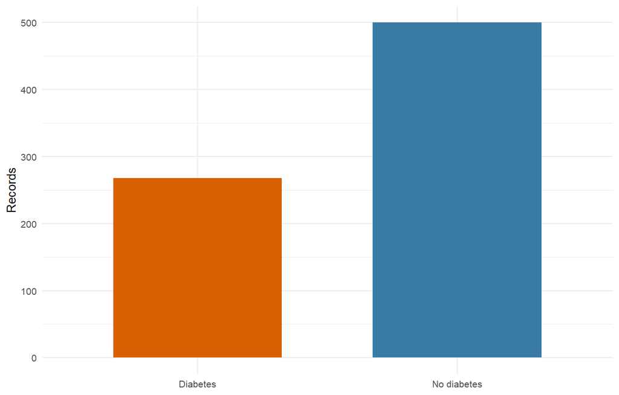

Outcome distribution.

# Methods

Zeros are converted to missing for clinical fields where zero is biologically implausible. Median imputation is learned only on the training set. Logistic regression uses standardized predictors, making coefficient magnitudes comparable. A decision tree is included as an interpretable nonlinear baseline.

The main validation split is stratified 80/20. Cross-validation uses five stratified folds on the training data.

# Results

## Holdout Metrics

Holdout model metrics at threshold 0.50.

| Model | Accuracy | Sensitivity | Specificity | Precision | F1 | ROC-AUC |
| --- | --- | --- | --- | --- | --- | --- |
| logistic | 83.8% | 64.8% | 94.0% | 85.4% | 73.7% | 0.916 |
| tree | 77.3% | 72.2% | 80.0% | 66.1% | 69.0% | 0.845 |

## Confusion Matrix

Selected-model holdout confusion matrix.

| Observed | Predicted | Records |
| --- | --- | --- |
| No diabetes | No diabetes | 94 |
| No diabetes | Diabetes | 6 |
| Diabetes | No diabetes | 19 |
| Diabetes | Diabetes | 35 |

## ROC Curve

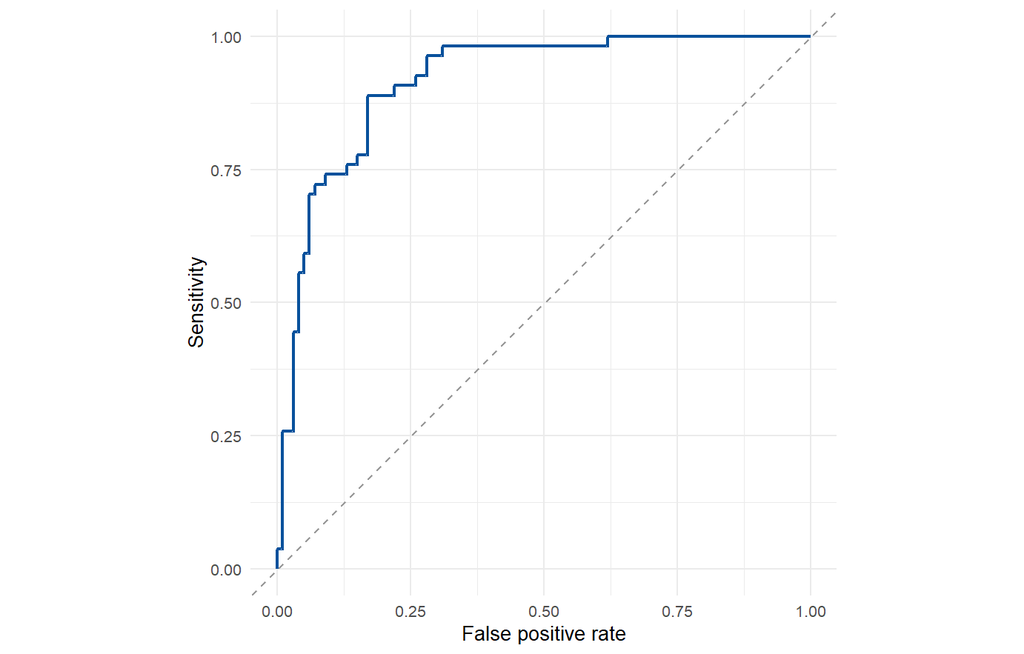

Selected-model ROC curve.

## Cross-Validation

Five-fold cross-validation summary.

| Model | Accuracy | Sensitivity | Specificity | F1 | Mean ROC-AUC |
| --- | --- | --- | --- | --- | --- |
| logistic | 74.4% | 52.4% | 86.2% | 59.0% | 0.814 |
| tree | 72.8% | 58.4% | 80.5% | 59.8% | 0.769 |

## Variable Interpretation

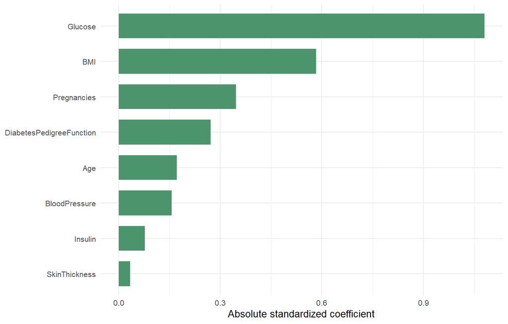

Logistic regression variable importance.

Standardized logistic regression coefficients.

| Variable | Coefficient | Direction |
| --- | --- | --- |
| Glucose | 1.081 | Higher probability |
| BMI | 0.583 | Higher probability |
| Pregnancies | 0.347 | Higher probability |
| DiabetesPedigreeFunction | 0.272 | Higher probability |
| Age | 0.172 | Higher probability |
| BloodPressure | -0.157 | Lower probability |
| Insulin | -0.078 | Lower probability |
| SkinThickness | 0.034 | Higher probability |

## Calibration

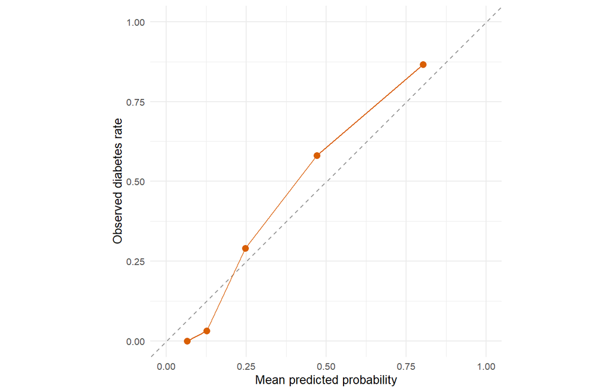

Calibration bins for the selected model.

# Discussion

The selected model provides a useful benchmark for classification and interpretation. Logistic regression is especially appropriate for a portfolio health example because it is transparent: the analyst can inspect direction and relative magnitude of standardized coefficients.

The confusion matrix is as important as ROC-AUC. Depending on whether the intended use is screening, triage, or general risk scoring, the threshold would need to be chosen differently. This project keeps the threshold at 0.50 and reports sensitivity and specificity clearly.

# Limitations

This dataset is small, historical, and population-specific. It is not representative of Brazil or of general clinical practice. The model does not include symptoms, medication history, laboratory follow-up, social determinants, or clinician review. The output must not be interpreted as diagnosis or medical advice.

# Conclusion

S13 delivers a complete, reproducible diabetes classification workflow with careful preprocessing, stratified validation, model comparison, ROC-AUC, calibration, and interpretation. The strongest portfolio signal is not only the model score, but the responsible framing of what the model can and cannot mean.

# References

Kaggle Pima Indians Diabetes Database. https://www.kaggle.com/datasets/uciml/pima-indians-diabetes-database

Public CSV mirror used for local reproducibility. https://raw.githubusercontent.com/npradaschnor/Pima-Indians-Diabetes-Dataset/master/diabetes.csv

Smith, J. W., et al. (1988). Using the ADAP learning algorithm to forecast the onset of diabetes mellitus.